# K-nearest Neighbor

# Prerequisites

```r
# Helper packages
library(dplyr)      # for data wrangling
library(ggplot2)    # for awesome graphics
library(rsample)    # for creating validation splits
library(recipes)    # for feature engineering

# Modeling packages
library(caret)       # for fitting KNN models
```

```r
# Ames housing data
ames <- AmesHousing::make_ames()
set.seed(123)
split  <- rsample::initial_split(ames, prop = 0.7, strata = "Sale_Price")
ames_train  <- rsample::training(split)

# create training (70%) set for the rsample::attrition data.
library(modeldata)
data(attrition)
attrit <- attrition %>% mutate_if(is.ordered, factor, ordered = FALSE)
set.seed(123)
churn_split <- initial_split(attrit, prop = .7, strata = "Attrition")
churn_train <- training(churn_split)

# import MNIST training data
mnist <- dslabs::read_mnist()
names(mnist)
```

```
[1] "train" "test"
```

# Measuring similarity

- KNN algorithm identifies $k$ observations that are “similar” or nearest to the new record being predicted
- Real estate analogy –> determine what price they will list (or market) a home for based on “comps” (comparable homes)
- Homes that have very similar attributes to the one being sold (e.g., square footage, number of rooms, style of the home, neighborhood and school district)

[interactive chart not shown]

# Distance measures

How do we determine the similarity between observations (or homes as in the previous example)?

To illustrate let’s look at two homes:

```r
(two_houses <- ames_train[1:2, c("Gr_Liv_Area", "Year_Built")])
```

| Gr_Liv_Area | Year_Built |
| --- | --- |
| 1656 | 1960 |
| 896 | 1961 |

How do we determine the similarity between observations (or homes as in the previous example)?

$$\text{Euclidean: }\sqrt{\sum^P_{j=1}(x_{aj} - x_{bj})^2}$$

```r
dist(two_houses, method = "euclidean")
```

```
         1
2 760.0007
```

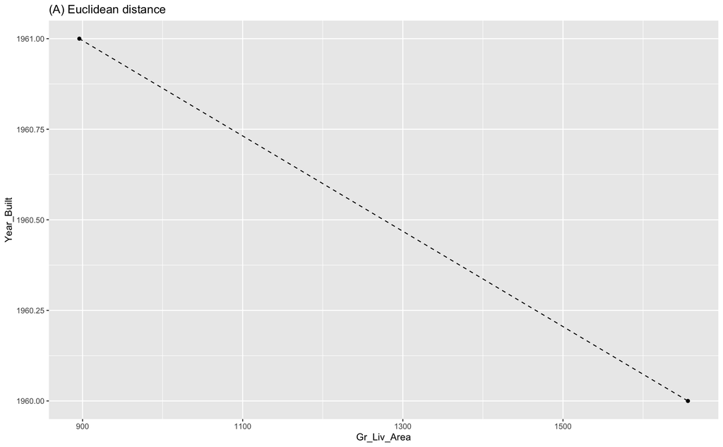

$$\text{Manhattan: }\sum^P_{j=1} | x_{aj} - x_{bj} |$$

```r
dist(two_houses, method = "manhattan")
```

```
    1
2 761
```

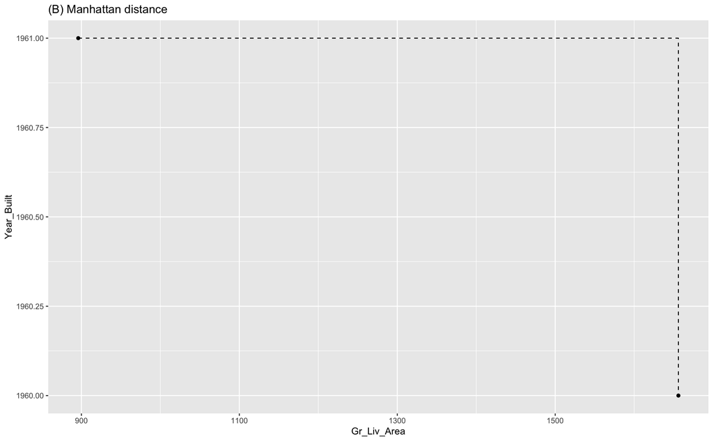

- For example, consider the three home below: `home1` is a four bedroom built in 2008, `home2` is a two bedroom built in the same year, and `home3` is a three bedroom built a decade earlier.

```r
home1
```

| home | Bedroom_AbvGr | Year_Built | id |
| --- | --- | --- | --- |
| home1 | 4 | 2008 | 423 |

```r
home2
```

| home | Bedroom_AbvGr | Year_Built | id |
| --- | --- | --- | --- |
| home2 | 2 | 2008 | 424 |

```r
home3
```

| home | Bedroom_AbvGr | Year_Built | id |
| --- | --- | --- | --- |
| home3 | 3 | 1998 | 6 |

```r
features <- c("Bedroom_AbvGr", "Year_Built")

# distance between home 1 and 2
dist(rbind(home1[,features], home2[,features]))
```

```
  1
2 2
```

```r
# distance between home 1 and 3
dist(rbind(home1[,features], home3[,features]))
```

```
         1
2 10.04988
```

- Standardizing eliminates these magnitude differences.

```r
scaled_ames <- recipe(Sale_Price ~ ., ames_train) %>%
  step_center(all_numeric()) %>%
  step_scale(all_numeric()) %>%
  prep(training = ames, retain = TRUE) %>%
  juice()

home1_std <- scaled_ames %>%
  mutate(id = row_number()) %>%
  filter(id == home1$id) %>%
  select(Bedroom_AbvGr, Year_Built, id) %>%
  mutate(home = "home1") %>%
  select(home, everything())

home2_std <- scaled_ames %>%
  mutate(id = row_number()) %>%
  filter(id == home2$id) %>%
  select(Bedroom_AbvGr, Year_Built, id) %>%
  mutate(home = "home2") %>%
  select(home, everything())

home3_std <- scaled_ames %>%
  mutate(id = row_number()) %>%
  filter(id == home3$id) %>%
  select(Bedroom_AbvGr, Year_Built, id) %>%
  mutate(home = "home3") %>%
  select(home, everything())
```

```r
home1_std
```

| home | Bedroom_AbvGr | Year_Built | id |
| --- | --- | --- | --- |
| home1 | 1.384186 | 1.211547 | 423 |

```r
home2_std
```

| home | Bedroom_AbvGr | Year_Built | id |
| --- | --- | --- | --- |
| home2 | -1.032058 | 1.211547 | 424 |

```r
home3_std
```

| home | Bedroom_AbvGr | Year_Built | id |
| --- | --- | --- | --- |
| home3 | 0.1760642 | 0.8809181 | 6 |

```r
# distance between home 1 and 2
dist(rbind(home1_std[,features], home2_std[,features]))
```

```
         1
2 2.416244
```

```r
# distance between home 1 and 3
dist(rbind(home1_std[,features], home3_std[,features]))
```

```
         1
2 1.252547
```

Pro Tip: When using KNN for classification, it is best to assess odd numbers for $k$ to avoid ties in the event there is equal proportion of response levels.

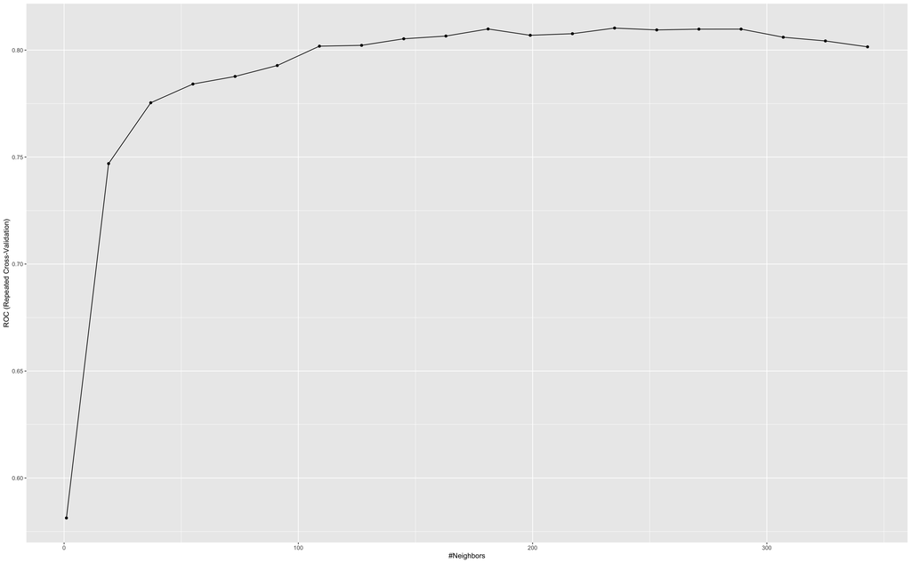

```r
# Create blueprint
blueprint <- recipe(Attrition ~ ., data = churn_train) %>%
  step_nzv(all_nominal()) %>%
  step_integer(contains("Satisfaction")) %>%
  step_integer(WorkLifeBalance) %>%
  step_integer(JobInvolvement) %>%
  step_dummy(all_nominal(), -all_outcomes(), one_hot = TRUE) %>%
  step_center(all_numeric(), -all_outcomes()) %>%
  step_scale(all_numeric(), -all_outcomes())

# Create a resampling method
cv <- trainControl(
  method = "repeatedcv",
  number = 10,
  repeats = 5,
  classProbs = TRUE,
  summaryFunction = twoClassSummary
)

# Create a hyperparameter grid search
hyper_grid <- expand.grid(
  k = floor(seq(1, nrow(churn_train)/3, length.out = 20))
)

# Fit knn model and perform grid search
knn_grid <- train(
  blueprint,
  data = churn_train,
  method = "knn",
  trControl = cv,
  tuneGrid = hyper_grid,
  metric = "ROC"
)

ggplot(knn_grid)
```

# MNIST

- Due to size let’s just take a subset

```r
set.seed(123)
index <- sample(nrow(mnist$train$images), size = 10000)
mnist_x <- mnist$train$images[index, ]
mnist_y <- factor(mnist$train$labels[index])
```

- Due to size let’s just take a subset
- Lots of near-zero variance features

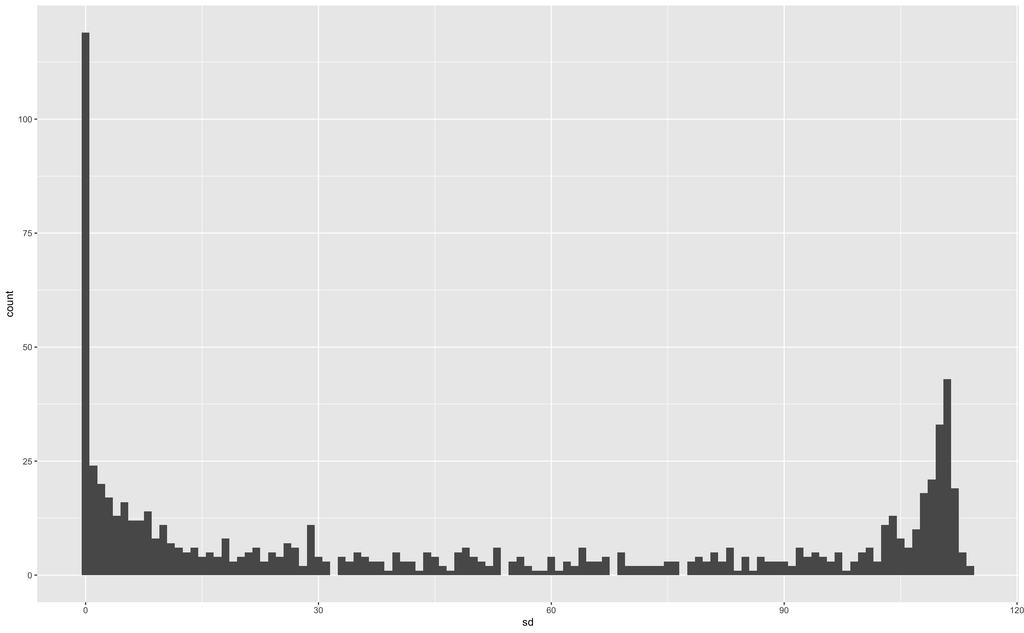

```r
mnist_x %>%
  as.data.frame() %>%
  purrr::map_df(sd) %>%
  gather(feature, sd) %>%
  ggplot(aes(sd)) +
  geom_histogram(binwidth = 1)
```

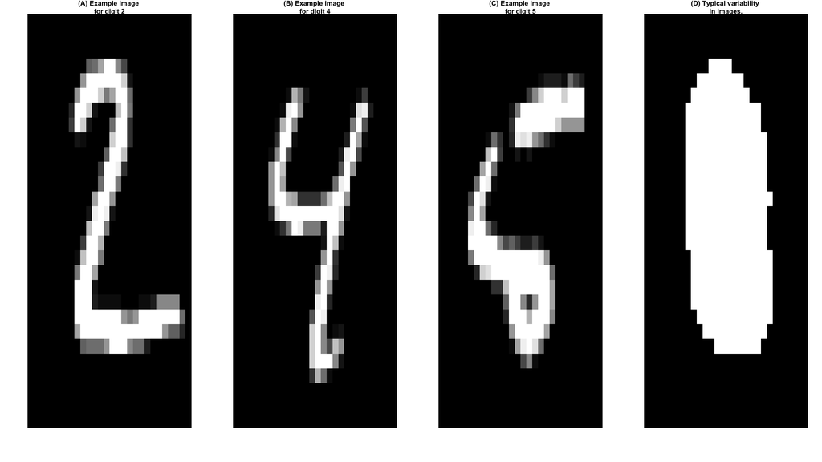

```r
# Rename features
colnames(mnist_x) <- paste0("V", 1:ncol(mnist_x))

# Remove near zero variance features manually
nzv <- nearZeroVar(mnist_x)
index <- setdiff(1:ncol(mnist_x), nzv)
mnist_x <- mnist_x[, index]
```

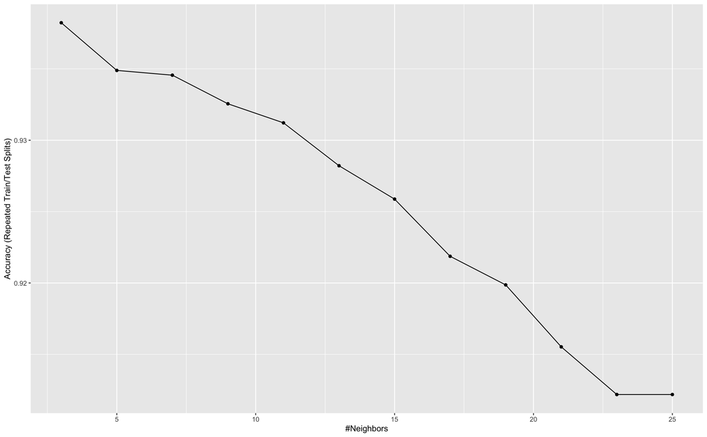

```r
# Use train/validate resampling method
cv <- trainControl(
  method = "LGOCV",
  p = 0.7,
  number = 1,
  savePredictions = TRUE
)

# Create a hyperparameter grid search
hyper_grid <- expand.grid(k = seq(3, 25, by = 2))

# Execute grid search
knn_mnist <- train(
  mnist_x,
  mnist_y,
  method = "knn",
  tuneGrid = hyper_grid,
  preProc = c("center", "scale"),
  trControl = cv
)

ggplot(knn_mnist)
```

# Results

```r
# Create confusion matrix
cm <- confusionMatrix(knn_mnist$pred$pred, knn_mnist$pred$obs)
cm$byClass[, c(1:2, 11)]  # sensitivity, specificity, & accuracy
```

```
         Sensitivity Specificity Balanced Accuracy
Class: 0   0.9641638   0.9962374         0.9802006
Class: 1   0.9916667   0.9841210         0.9878938
Class: 2   0.9155666   0.9955114         0.9555390
Class: 3   0.9163952   0.9920325         0.9542139
Class: 4   0.8698630   0.9960538         0.9329584
Class: 5   0.9151404   0.9914891         0.9533148
Class: 6   0.9795322   0.9888684         0.9842003
Class: 7   0.9326520   0.9896962         0.9611741
Class: 8   0.8224382   0.9978798         0.9101590
Class: 9   0.9329897   0.9852687         0.9591292
```

# Visualizing correct & incorrect predictions

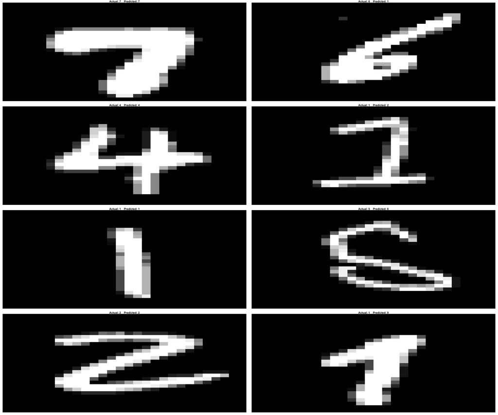

```r
# Get a few accurate predictions
set.seed(9)
good <- knn_mnist$pred %>%
  filter(pred == obs) %>%
  sample_n(4)

# Get a few inaccurate predictions
set.seed(9)
bad <- knn_mnist$pred %>%
  filter(pred != obs) %>%
  sample_n(4)

combine <- bind_rows(good, bad)

# Get original feature set with all pixel features
set.seed(123)
index <- sample(nrow(mnist$train$images), 10000)
X <- mnist$train$images[index,]

# Plot results
par(mfrow = c(4, 2), mar=c(1, 1, 1, 1))
layout(matrix(seq_len(nrow(combine)), 4, 2, byrow = FALSE))
for(i in seq_len(nrow(combine))) {
  image(matrix(X[combine$rowIndex[i],], 28, 28)[, 28:1],
        col = gray(seq(0, 1, 0.05)),
        main = paste("Actual:", combine$obs[i], "  ",
                     "Predicted:", combine$pred[i]),
        xaxt="n", yaxt="n")
}
```

# Summary

- KNNs are a very simplistic, and intuitive, algorithm that can provide average to decent predictive power, especially when the response is dependent on the local structure of the features
- Major drawback of KNNs is their computation time, which increases by $n \times p$ for each observation
- Furthermore, since KNNs are a lazy learner, they require the model be run at prediction time which limits their use for real-time modeling
- Although KNNs rarely provide the best predictive performance, they have many benefits, for example, in feature engineering and in data cleaning and preprocessing